# Assignment 8

gzahn

March 23, 2019

# **Assignment 8**

In this assignment, you will use R (within R-Studio) to:

- Load and clean a real data set
- Conduct exploratory analyses, including informative figures
- Build and test appropriate models
- Draw conclusions about your data
- Combine all of the above into a well-documented R-Markdown report and export (knit) it into an HTML file

**All file paths should be relative, starting from the Assignment_8 directory!! (where you found this file)**

**This means that you need to create a new R-Project named “Assignment_8.Rproj” in your Assignment_8 directory, and work from scripts within that.**

## **For credit…**

1. Push a completed version of your Rproj and R-markdown file (details at end of this assignment) to GitHub
2. Your score will also depend on your analyses and presentation of your final report

# Your tasks:

- Use the data set “../../Data/GradSchool_Admissions.csv”

```r
df=read.csv("./GradSchool_Admissions.csv")
library(tidyverse)
library(MASS)
library(modelr)
```

- You will explore and model the predictors of graduate school admission
- the “admit” column is coded as 1=success and 0=failure
- the other columns are the GRE score, the GPA, and the rank of the undergraduate institution, where I is “top-tier.”
- Document your data explorations, figures, and conclusions in a reproducible R-markdown report

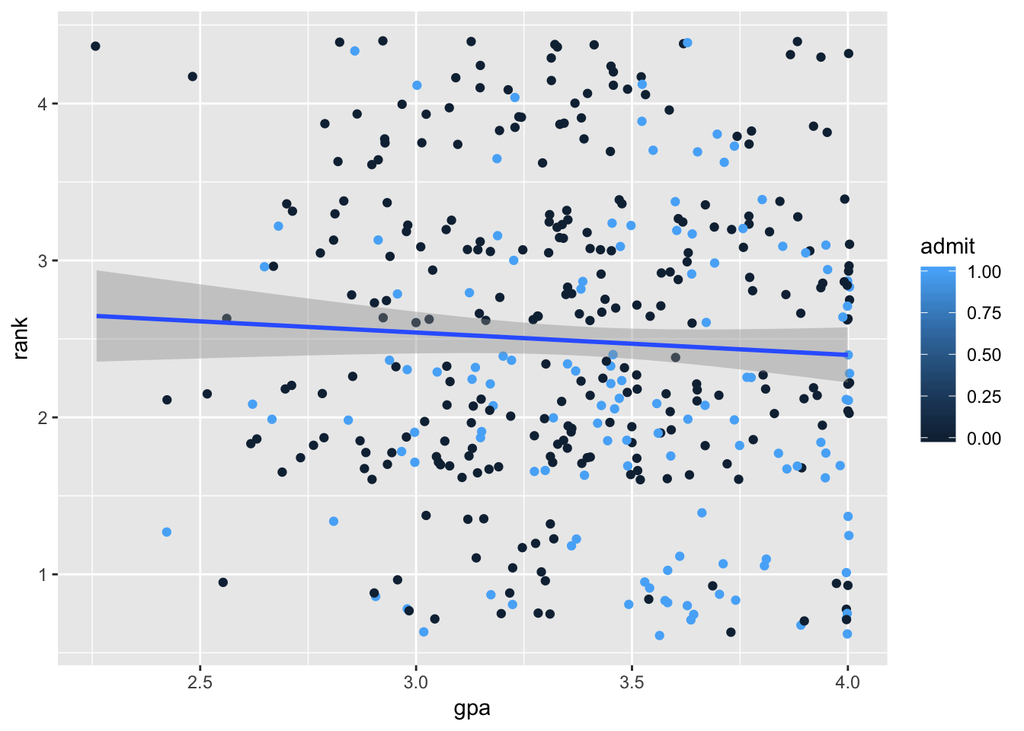

```r
ggplot(df, aes(x=gpa,y=rank,col=admit)) + geom_jitter() + geom_smooth(method="lm")
```

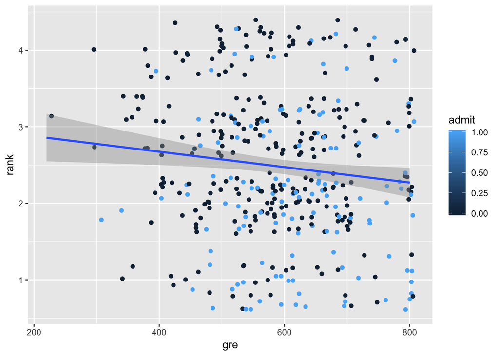

```r
ggplot(df, aes(x=gre,y=rank,col=admit)) + geom_jitter() + geom_smooth(method="lm")
```

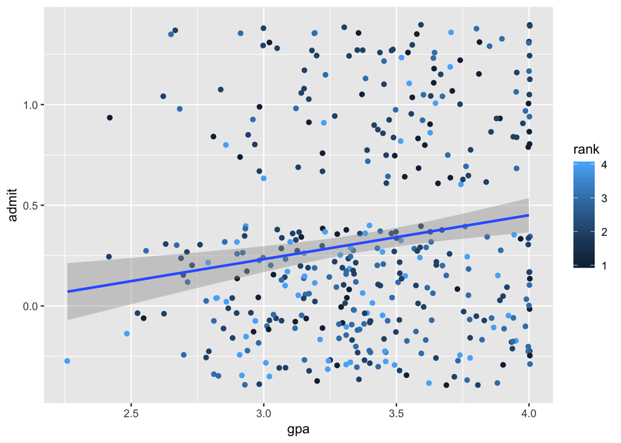

```r
ggplot(df, aes(x=gpa,y=admit,col=rank)) + geom_jitter() + geom_smooth(method="lm")
```

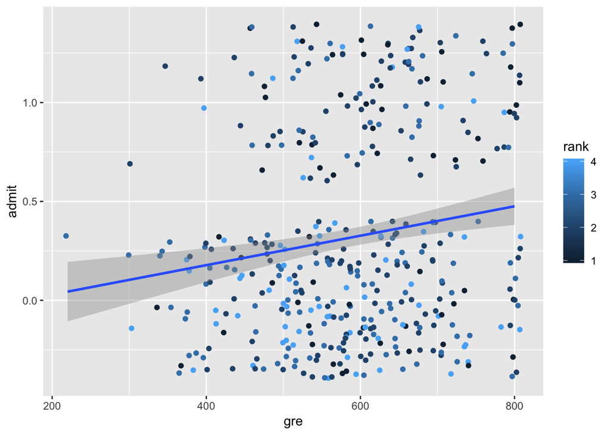

```r
ggplot(df, aes(x=gre,y=admit,col=rank)) + geom_jitter() + geom_smooth(method="lm")
```

```r
mod1 = lm(admit ~ gre + gpa + rank, data = df)
summary(mod1)
```

```
##
## Call:
## lm(formula = admit ~ gre + gpa + rank, data = df)
##
## Residuals:
##     Min      1Q  Median      3Q     Max
## -0.6617 -0.3417 -0.1947  0.5061  0.9556
##
## Coefficients:
##               Estimate Std. Error t value Pr(>|t|)
## (Intercept) -0.1824127  0.2169695  -0.841   0.4010
## gre          0.0004424  0.0002101   2.106   0.0358 *
## gpa          0.1510402  0.0633854   2.383   0.0176 *
## rank        -0.1095019  0.0237617  -4.608 5.48e-06 ***
## ---
## Signif. codes:  0 '***' 0.001 '**' 0.01 '*' 0.05 '.' 0.1 ' ' 1
##
## Residual standard error: 0.4448 on 396 degrees of freedom
## Multiple R-squared:  0.09601,    Adjusted R-squared:  0.08916
## F-statistic: 14.02 on 3 and 396 DF,  p-value: 1.054e-08
```

```r
mod2 = lm(admit ~ gre + gpa, data = df)
summary(mod2)
```

```
##
## Call:
## lm(formula = admit ~ gre + gpa, data = df)
##
## Residuals:
##     Min      1Q  Median      3Q     Max
## -0.5281 -0.3403 -0.2345  0.5757  0.9252
##
## Coefficients:
##               Estimate Std. Error t value Pr(>|t|)
## (Intercept) -0.5279342  0.2087277  -2.529   0.0118 *
## gre          0.0005489  0.0002141   2.564   0.0107 *
## gpa          0.1542363  0.0649769   2.374   0.0181 *
## ---
## Signif. codes:  0 '***' 0.001 '**' 0.01 '*' 0.05 '.' 0.1 ' ' 1
##
## Residual standard error: 0.456 on 397 degrees of freedom
## Multiple R-squared:  0.04753,    Adjusted R-squared:  0.04274
## F-statistic: 9.906 on 2 and 397 DF,  p-value: 6.333e-05
```

```r
mod3 = lm(admit ~ gpa + rank, data = df)
summary(mod3)
```

```
##
## Call:
## lm(formula = admit ~ gpa + rank, data = df)
##
## Residuals:
##     Min      1Q  Median      3Q     Max
## -0.6114 -0.3461 -0.2099  0.5036  0.9637
##
## Coefficients:
##             Estimate Std. Error t value Pr(>|t|)
## (Intercept) -0.08100    0.21247  -0.381 0.703252
## gpa          0.20186    0.05887   3.429 0.000669 ***
## rank        -0.11501    0.02372  -4.849 1.79e-06 ***
## ---
## Signif. codes:  0 '***' 0.001 '**' 0.01 '*' 0.05 '.' 0.1 ' ' 1
##
## Residual standard error: 0.4467 on 397 degrees of freedom
## Multiple R-squared:  0.08589,    Adjusted R-squared:  0.08128
## F-statistic: 18.65 on 2 and 397 DF,  p-value: 1.813e-08
```

```r
df = add_predictions(df, mod1, var= "mod1")
df = add_predictions(df, mod2, var= "mod2")
df = add_predictions(df, mod3, var="mod3")



df=mutate(df, DIFF1 = abs(mod1 -admit))
df=mutate(df, DIFF2 = abs(mod2 -admit))
df=mutate(df, DIFF3 = abs(mod3 -admit))
```

Predit which one is the best to use

```r
mean(df$DIFF1)
```

```
## [1] 0.3927958
```

```r
mean(df$DIFF2)
```

```
## [1] 0.4127868
```

```r
mean(df$DIFF3)
```

```
## [1] 0.3967904
```

```r
anova(mod1, mod2)
```

|  | Res.Df | RSS | Df | Sum of Sq | F | Pr(>F) |
| --- | --- | --- | --- | --- | --- | --- |
| 1 | 396 | 78.35530 | NA | NA | NA | NA |
| 2 | 397 | 82.55737 | -1 | -4.202062 | 21.23681 | 5.48229e-06 |

```r
anova(mod2, mod3)
```

|  | Res.Df | RSS | Df | Sum of Sq | F | Pr(>F) |
| --- | --- | --- | --- | --- | --- | --- |
| 1 | 397 | 82.55737 | NA | NA | NA | NA |
| 2 | 397 | 79.23285 | 0 | 3.324516 | NA | NA |

```r
anova(mod1,mod3)
```

|  | Res.Df | RSS | Df | Sum of Sq | F | Pr(>F) |
| --- | --- | --- | --- | --- | --- | --- |
| 1 | 396 | 78.35530 | NA | NA | NA | NA |
| 2 | 397 | 79.23285 | -1 | -0.8775462 | 4.435032 | 0.03583749 |

```r
stepAIC(mod1)
```

```
## Start:  AIC=-644.08
## admit ~ gre + gpa + rank
##
##        Df Sum of Sq    RSS     AIC
## <none>              78.355 -644.08
## - gre   1    0.8775 79.233 -641.63
## - gpa   1    1.1235 79.479 -640.39
## - rank  1    4.2021 82.557 -625.19
```

```
##
## Call:
## lm(formula = admit ~ gre + gpa + rank, data = df)
##
## Coefficients:
## (Intercept)          gre          gpa         rank
##  -0.1824127    0.0004424    0.1510402   -0.1095019
```

```r
stepAIC(mod2)
```

```
## Start:  AIC=-625.19
## admit ~ gre + gpa
##
##        Df Sum of Sq    RSS     AIC
## <none>              82.557 -625.19
## - gpa   1    1.1717 83.729 -621.55
## - gre   1    1.3673 83.925 -620.62
```

```
##
## Call:
## lm(formula = admit ~ gre + gpa, data = df)
##
## Coefficients:
## (Intercept)          gre          gpa
##  -0.5279342    0.0005489    0.1542363
```

```r
stepAIC(mod3)
```

```
## Start:  AIC=-641.63
## admit ~ gpa + rank
##
##        Df Sum of Sq    RSS     AIC
## <none>              79.233 -641.63
## - gpa   1    2.3469 81.580 -631.95
## - rank  1    4.6918 83.925 -620.62
```

```
##
## Call:
## lm(formula = admit ~ gpa + rank, data = df)
##
## Coefficients:
## (Intercept)          gpa         rank
##     -0.0810       0.2019      -0.1150
```

```r
df = add_predictions(df, mod1, var= "mod1")
df = add_predictions(df, mod2, var= "mod2")
df = add_predictions(df, mod3, var="mod3")
```

Graph of the different predictive models Mod1 = Red Mod2 = Blue Mod3 = Green

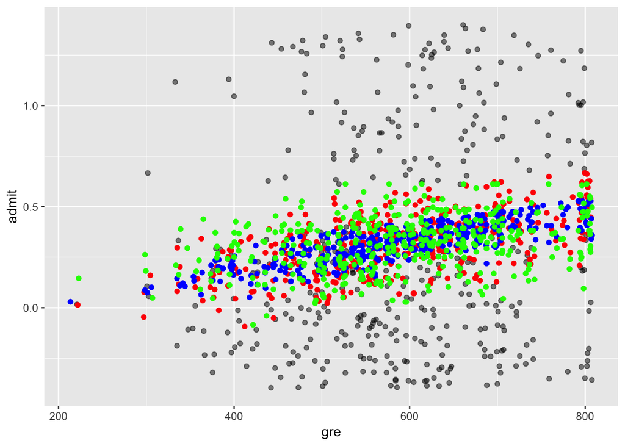

```r
ggplot(df, aes(x=gre)) +
  geom_jitter(aes(y=admit), alpha=.5) +
  geom_jitter(aes(y=mod1), color="Red") +
  geom_jitter(aes(y=mod2), color="Blue") +
  geom_jitter(aes(y=mod3), color="Green")
```

Just for fun does GPA predit GRE Scores?

```r
mod4 =lm(gre ~ gpa, data= df)
summary(mod4)
```

```
##
## Call:
## lm(formula = gre ~ gpa, data = df)
##
## Residuals:
##      Min       1Q   Median       3Q      Max
## -302.394  -62.789   -2.206   68.506  283.438
##
## Coefficients:
##             Estimate Std. Error t value Pr(>|t|)
## (Intercept)   192.30      47.92   4.013 7.15e-05 ***
## gpa           116.64      14.05   8.304 1.60e-15 ***
## ---
## Signif. codes:  0 '***' 0.001 '**' 0.01 '*' 0.05 '.' 0.1 ' ' 1
##
## Residual standard error: 106.8 on 398 degrees of freedom
## Multiple R-squared:  0.1477, Adjusted R-squared:  0.1455
## F-statistic: 68.95 on 1 and 398 DF,  p-value: 1.596e-15
```

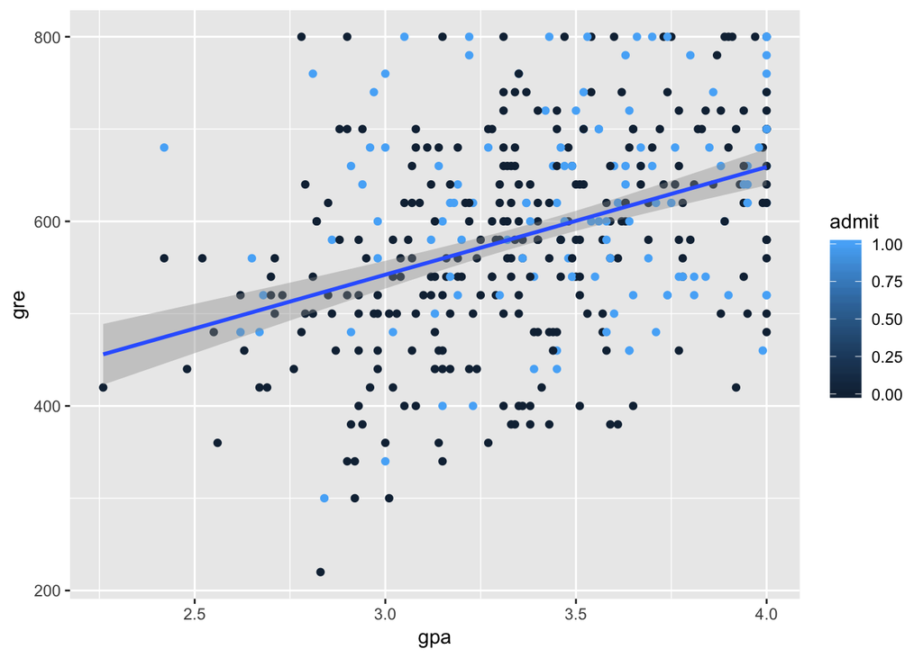

```r
ggplot(df, aes(x=gpa,y=gre,col=admit)) +geom_point() + geom_smooth(method="lm")
```